# Breast Cancer Wisconsin (Diagnostic)

In this project, I aim to classify breast cancer tumors as benign or malignant using Decision Tree and Random Forest models.  
We will analyze the data, clean it, create models, tune hyperparameters, and evaluate the results.

Firstly, I import my dataset, check the columns, and remove unnecessary ones.

```r
data <- read.csv("C:\\Users\\damla\\OneDrive\\Belgeler\\GitHub\\R\\PROJE\\TREES\\data.csv")
View(data)
names(data)
```

```
 [1] "id"                      "diagnosis"
 [3] "radius_mean"             "texture_mean"
 [5] "perimeter_mean"          "area_mean"
 [7] "smoothness_mean"         "compactness_mean"
 [9] "concavity_mean"          "concave.points_mean"
[11] "symmetry_mean"           "fractal_dimension_mean"
[13] "radius_se"               "texture_se"
[15] "perimeter_se"            "area_se"
[17] "smoothness_se"           "compactness_se"
[19] "concavity_se"            "concave.points_se"
[21] "symmetry_se"             "fractal_dimension_se"
[23] "radius_worst"            "texture_worst"
[25] "perimeter_worst"         "area_worst"
[27] "smoothness_worst"        "compactness_worst"
[29] "concavity_worst"         "concave.points_worst"
[31] "symmetry_worst"          "fractal_dimension_worst"
[33] "X"
```

```r
data <- data[-c(33)]
```

Then, I check if there are any missing values.

```
 /\     /\
{  `---'  }
{  O   O  }
==>  V <==  No need for mice. This data set is completely observed.
 \  \|/  /
  `-----'

    id diagnosis radius_mean texture_mean perimeter_mean area_mean
569  1         1           1            1              1         1
     0         0           0            0              0         0
    smoothness_mean compactness_mean concavity_mean
569               1                1              1
                  0                0              0
    concave.points_mean symmetry_mean fractal_dimension_mean
569                   1             1                      1
                      0             0                      0
    radius_se texture_se perimeter_se area_se smoothness_se
569         1          1            1       1             1
            0          0            0       0             0
    compactness_se concavity_se concave.points_se symmetry_se
569              1            1                 1           1
                 0            0                 0           0
    fractal_dimension_se radius_worst texture_worst perimeter_worst
569                    1            1             1               1
                       0            0             0               0
    area_worst smoothness_worst compactness_worst concavity_worst
569          1                1                 1               1
             0                0                 0               0
    concave.points_worst symmetry_worst fractal_dimension_worst
569                    1              1                       1 0
                       0              0                       0 0
```

[figure not shown]

```r
library(mice)
md.pattern(data)
```

I load the libraries required for building and evaluating decision trees.

```r
library(caret)
library(e1071)
library(rpart)
library(rattle)
```

Here, I split my dataset into 80% training and 20% testing data. Then, I check how many benign and malignant samples I have.

```r
set.seed(86)
trainIndex<-sample(1:nrow(data),0.8*nrow(data))
traindata<-data[trainIndex,]
testdata<-data[-trainIndex,]

traindata$diagnosis<-as.factor(traindata$diagnosis)
testdata$diagnosis<-as.factor(testdata$diagnosis)

table(traindata$diagnosis)
```

```
  B   M
278 177
```

```r
table(testdata$diagnosis)
```

```
 B  M
79 35
```

Now, I create two decision tree models — one using Information Gain and the other using the Gini Index.

Information Gain measures purity using entropy and chooses splits that give the most information about the target variable.

Gini Index measures how often a randomly chosen element would be incorrectly classified.

Gini is usually faster and works well with large datasets.

```r
model1<-rpart(diagnosis~.,data=traindata,method="class",
              parms=list(split="information"))

model2<-rpart(diagnosis~.,data=traindata,method="class",
              parms=list(split="gini"))
```

They are the plot of our model.

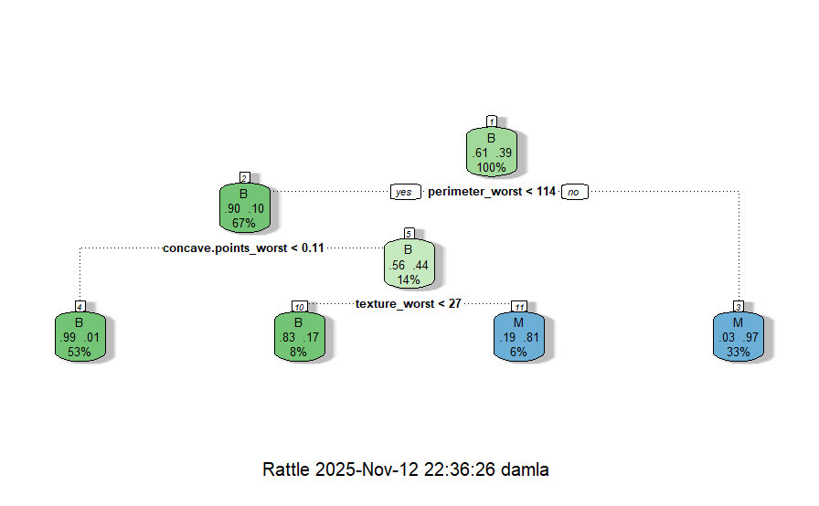

```r
fancyRpartPlot(model1)
```

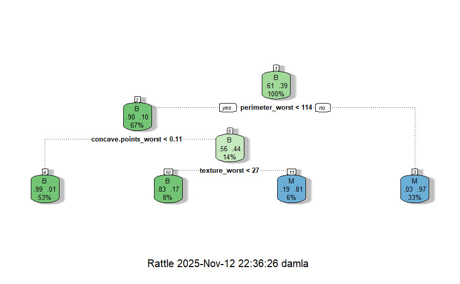

```r
fancyRpartPlot(model2)
```

I adjust parameters to prevent overfitting and improve performance.